# Визуализация в ggplot2

Громов В.П.

# Постановка задачи

С помощью скаченного файла `as.csv` построить графики зависимости *V5*, *V6*, *V7*, *V8* от *V1*.  
В качестве решения приложить код чтения данных и построения графиков. Зависимости *V5(V1)* и *V6(V1*) отобразить на одном графике.

## Решение (код)

Для работы программа требует подключение библиотеки **ggplot2**  
Что есть в программе:

1. Функция чтения данных из файла (`readData(source)`)
2. Функция построения графиков (`buildPlot(args)`)
3. Функция выбора нужных нам переменных по их названиям (`selectColumns(data, x, y , u)`)
4. Функция отображения графика (`printPlot = function(dataSource, x, y, u)`)

Что нужно программе для начала работы:

1. Указать путь до файла с данными
2. Выбрать от двух до трех переменных, по которым будут строиться графики.

### Подробнее о каждой функции

#### Ридер

```r
readData = function(source){
  data <- read.csv(source)
  return(data)
}
```

Ридеру задается путь до файла с разрешением `csv`. Он преобразует файл в датафрейм и выдает его в качестве результата работы функции.

#### Селектор

```r
selectColumns = function(data, x, y, u = NA){
  xIndex = grep(x, colnames(data))
  yIndex = grep(y, colnames(data))
  if(!is.na(u)){
    uIndex = grep(u, colnames(data))
    res = data.frame(data[,xIndex], data[,yIndex], data[,uIndex])
  }
  else{
    res = data.frame(data[,xIndex], data[,yIndex])
  }
  names(res) <- c(x, y)
  if(length(res) == 3)
    names(res)[3] <- u
  return(res)
}
```

Селектор принимает на вход от трех до четырех параметров. Первый параметр – это датафрейм, из которого мы будем выбирать нужные нам колонки. Следующие параметры – строковые, содержащие название нужных колонок. **ВАЖНО**: то, в каком порядке будут записаны названия в том же порядке они будут записаны в новый датафрейм. Результат работы данной функции – датафрейм с нужными нам колонками.

#### Билдер

```r
buildPlot = function(args){

  if(length(args) == 2){
    names = colnames(args, do.NULL = TRUE, prefix = "col")
    gplot = ggplot(data = args, aes(x = args[,1], y = args[,2])) + geom_line(size = 2, color = "forestgreen") +
      xlab(names[1]) + ylab(names[2])
    return(gplot)
  }

  else if(length(args) == 3){
    names = colnames(args, do.NULL = TRUE, prefix = "col")
    gplot = ggplot(data = args, aes(x = args[,1], y = args[,2], color = args[,3])) + geom_point(size = 2) +
      xlab(names[1]) + ylab(names[2]) + scale_color_gradient(low = "blue", high = "orange") + labs(colour = names[3])
    return(gplot)
  }
  else return()
}
```

Билдер занимается построением, но не отображением графика. Он настроен на три варианта:

1. Если аргумента два, то строит график по двум элементам
2. Если их три, то по трем
3. Если их меньше двух или больше трех, то ничего не делает

На вход принимает датафрейм. Нужно учитывать, что порядок колонок в датафрейме напряму влияет на то, как построится график. Первая колонка – ось **x**, вторая – ось **y**, если есть третья, то она варьирует цвет в зависимости от своего значения на оси **x**.  
Всем осям присвоены имена колонок, с которых взята информация. Возвращает эта функция `ggplot`.

#### Отображение графика

```r
printPlot = function(dataSource, x , y, u = NA){
  data = readData(dataSource)
  args = selectColumns(data, x, y, u)
  gplot = buildPlot(args)
  print(gplot)
}
```

По сути, это функция – собрание предыдущих. Для корректной работы ей нужны все данные, которые нужны были ее предшественникам, а именно:

1. Путь до файла, из которого будет браться информация
2. Названия от двух до трех колонок файла

На выходе эта функция строит график по заданным колонкам датафрема.

## Решение: итоговый код

```r
library(ggplot2)

#Читает информацию
readData = function(source){
  data <- read.csv(source)
  return(data)
}

#Строит, но не выводит графики
buildPlot = function(args){

  if(length(args) == 2){
    names = colnames(args, do.NULL = TRUE, prefix = "col")
    gplot = ggplot(data = args, aes(x = args[,1], y = args[,2])) + geom_line(size = 2, color = "forestgreen") +
      xlab(names[1]) + ylab(names[2])
    return(gplot)
  }

  else if(length(args) == 3){
    names = colnames(args, do.NULL = TRUE, prefix = "col")
    gplot = ggplot(data = args, aes(x = args[,1], y = args[,2], color = args[,3])) + geom_point(size = 2) +
      xlab(names[1]) + ylab(names[2]) + scale_color_gradient(low = "blue", high = "orange") + labs(colour = names[3])
    return(gplot)
  }
  else return()
}

#Отбирает нужные колонки по именам
selectColumns = function(data, x, y, u = NA){
  xIndex = grep(x, colnames(data))
  yIndex = grep(y, colnames(data))
  if(!is.na(u)){
    uIndex = grep(u, colnames(data))
    res = data.frame(data[,xIndex], data[,yIndex], data[,uIndex])
  }
  else{
    res = data.frame(data[,xIndex], data[,yIndex])
  }
  names(res) <- c(x, y)
  if(length(res) == 3)
    names(res)[3] <- u
  return(res)
}

#Функция построения графика
printPlot = function(dataSource, x, y, u = NA){
  data = readData(dataSource)
  args = selectColumns(data, x, y, u)
  gplot = buildPlot(args)
  print(gplot)
}
```

## Решение: графики зависимости

#### График V5(V1)

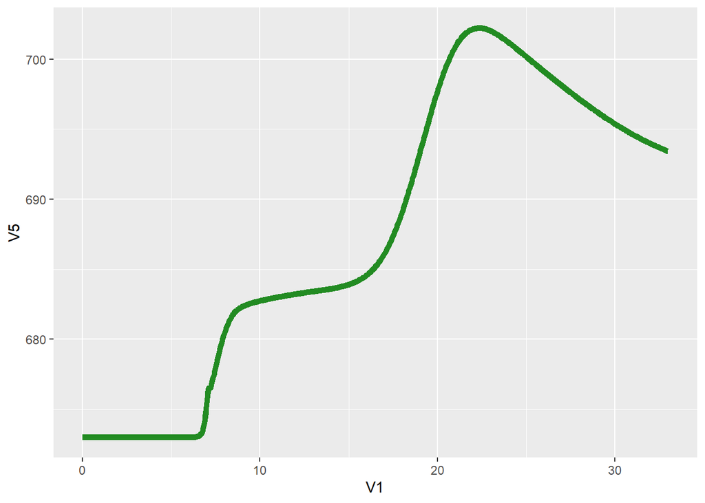

#### График V6(V1)

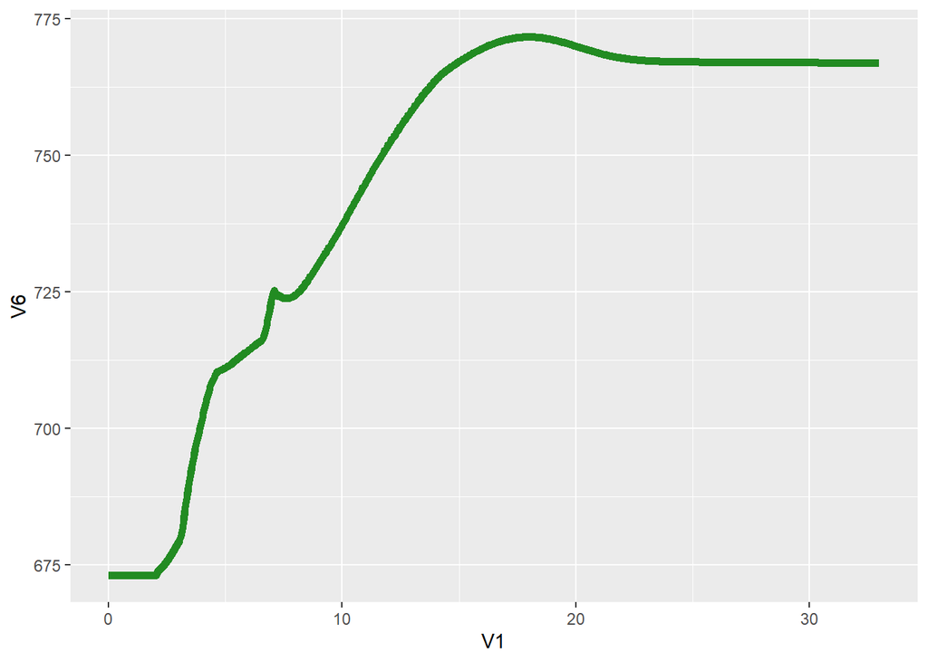

#### График V7(V1)

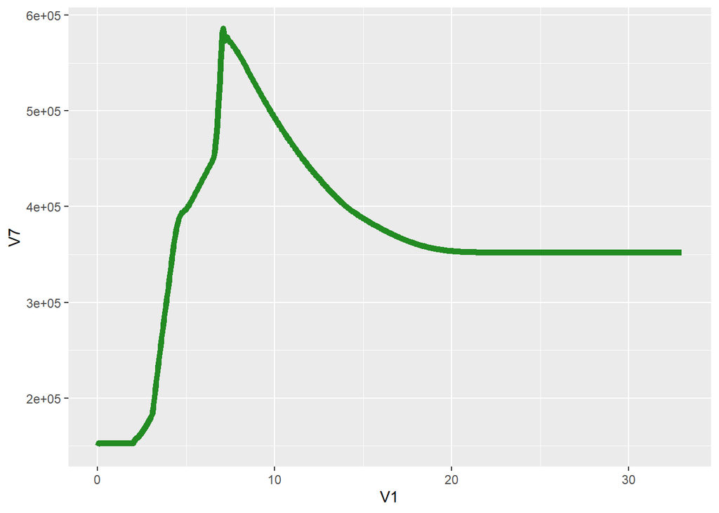

#### График V8(V1)

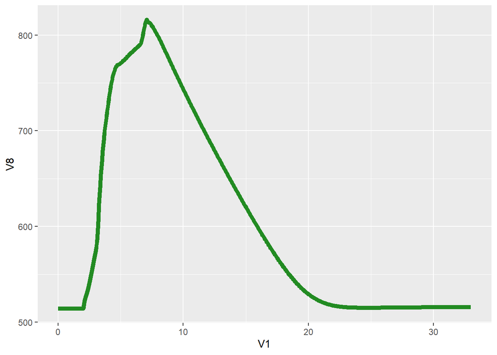

#### График V5(V1) и V6(V1)

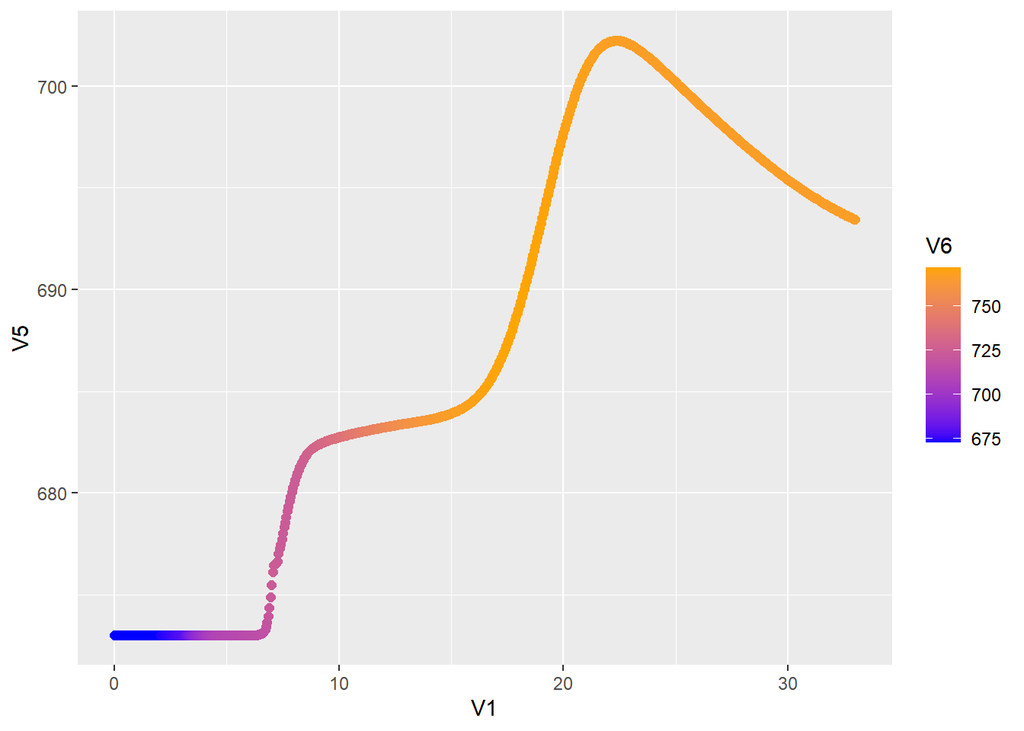